# Don’t Mess with the Original

Julia Lee, Stella Li, Irene Ryan

4/23/2018

[figure not shown]

The latest trend in Hollywood filmmaking seems to be the remake. 2018 saw recreations of Halloween, Robin Hood, Ready Player One, and a third How the Grinch Stole Christmas. Remakes have become a popular way to retell old stories through new lenses and reimagined characters. But is this lazy filmmaking? Can the remakes stand up to their predecessors? Our goal with this project was to see whether the perception we have about remakes is true. To measure this, we isolated the IMDB ratings for 59 movies and their remakes.

A remake is defined as an older, already existing plot told with different actors and might emphasize different themes but with the overall plot stays the same, like the cover of a song. Also, Hollywood remakes a movie for several potential reasons; maybe it is to update the original movie for a modern audience, maybe because of the lack of original ideas, or could be that audiences are more likely to see a movie when they already recognize the title. Hollywood entertainment companies have an tendency of creating remakes of movies that are blockbuster, expecting the remakes would create even more profit and positive reputation, but we are not sure whether these updates are actually effective?

Contrary to the companies’ ideal expectation for most of the time, it seems like when the first film is decent or even excellent, the second film just isn’t able to match up. Sometimes the studio tries to rush the sequel out, and that results in a rushed creative process; or the story ideas are just depleted, and the remake is just for the sake of making more profit. In general, it’s as simple as the remakes only focus on doing “bigger” instead of being “better”. Occasionally, the original film isn’t all that great, and the newer version blows it out of the water, exceeding far beyond everyone’s expectations.

```r
db<-dbConnect_scidb(dbname = "imdb")
dbListTables(db)
```

```r
remakesoriginals<-db %>%
dbGetQuery("SELECT t.id, t.title, t.production_year,
  mi1.info AS votes, mi2.info AS rating, mi3.info AS Budget, 'original' AS type, mi4.info AS Languages
FROM title t
JOIN movie_info_idx AS mi1 ON mi1.movie_id = t.id  #used  movie_id to join movie_info_idx to title
JOIN movie_link AS L on L.linked_movie_id = t.id  #used  linked_movie_id to join movie_link to title
JOIN movie_info AS mi3 ON mi3.movie_id = t.id    #used  movie_id to join movie_info to title
JOIN movie_info AS mi4 ON mi4.movie_id = t.id    #used  movie_id to join movie_info to title
JOIN movie_info_idx AS mi2 ON mi2.movie_id = t.id #used movie_id to join movie_info_idx to title

#used index here for speed
WHERE t.kind_id = 1 #limit only to movies
  AND mi1.info_type_id = 100 #only info aboutnumber_of_votes
  AND mi2.info_type_id = 101  # only info about rating
  AND mi3.info_type_id = 105  # only info about Budget
AND mi4.info = 'English' #used index limit movie to only english_language films
AND mi1.info >25000  #only films that got more than 25000 votes
group by t.id #group by t.id(because this gives us the disnict film but it could have same title);")

fav_stats(remakesoriginals$votes)
```

```r
#Eliminating and movies that show up more than twice (indicating it is not an original-remake pair)
list<-remakesoriginals%>%
  group_by(title)%>%
  summarise(number=n())%>%
  filter(number==2)

#Joining with the remakesoriginals table to get the title
test<-list%>%
  inner_join(remakesoriginals, by="title")

#eliminating movies showing up in the same year (not a remake, just share the same name)
finallist<-test%>%
  group_by(title)%>%
  summarise(distinctyr=n_distinct(production_year))%>%
  filter(distinctyr==2)

#Rejoining titles, changing rating and vote variables to numeric
mp4<-finallist%>%
  inner_join(remakesoriginals, by="title")%>%
  select(-type)
mp4$votes <-as.numeric(mp4$votes)
mp4$rating <-as.numeric(mp4$rating)
```

```r
# deleting the original movie
remakesmp4 <- mp4[c(rep(FALSE,1),TRUE), ]
# deleting the remakes
originalsmp4<-mp4[c(rep(TRUE,1), FALSE),]

# join the two df and create a new column representing the difference in vote and rating
full<-remakesmp4%>%
  left_join(originalsmp4, by="title") %>%
  mutate (diff_rating = rating.x - rating.y) %>%
  mutate (diff_votes = votes.x - votes.y) %>%
  mutate (which = ifelse(diff_rating > 0,"remake", "original" ))
#removing two leftover cases after aggregating (Crash, Legend, Passengers, The Avengers, The Gift, and Unknown)
plottingdata<-full[-c(11, 25, 30, 44, 47, 65),]
```

We gathered information about remakes of some previous movies, and joined the movie titles with additional information such as, id number, production year, number of votes, rating, budget, and languages. In the final table, we filtered out the movies that have the same titles with same production year, since we know for certain that the pairs would not be an original and a remake. Further, we filtered out some extreme small values of votes based on the average number of votes, in this case, we eliminated the remakes that happen to have the same title but are actually different movies.

```r
#creating a remake and original column for plotting
plottingdata[["betterrated"]]=ifelse(plottingdata[["diff_rating"]] >= 0, "Remake", "Original")
```

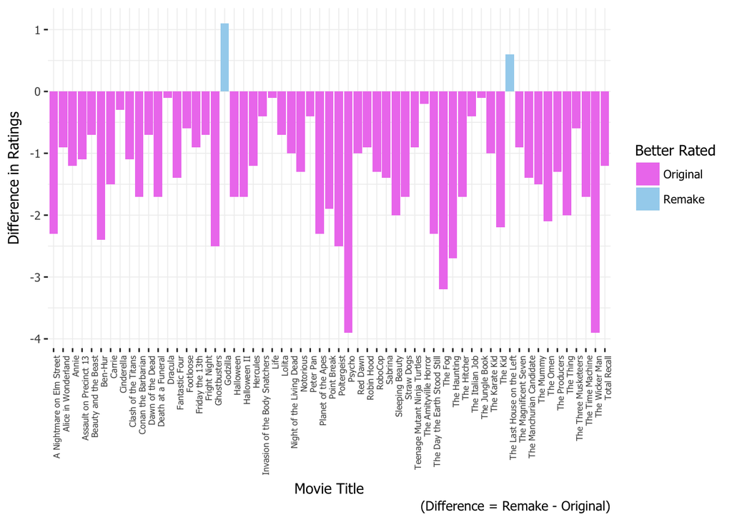

```r
#plot 1
ggplot(data = plottingdata, aes(x = title, y = diff_rating, fill = betterrated))+
  geom_col() + scale_fill_manual(values = c("Remake"="lightskyblue2", "Original"="violet"))+
  theme(text = element_text(size = 10, family="Tahoma"),
        axis.text.x = element_text(angle = 90, hjust = 1, size = 6),
        panel.grid.major = element_line(color = "gray94", size = .3),
  panel.grid.minor = element_line(color = "gray94", size = .3),
  panel.background = element_rect(fill = "white",
                                color = "white"))+
  scale_y_continuous(breaks = c(-4, -3, -2, -1, 0, 1), labels = c("-4", "-3", "-2", "-1", "0", "1"))+
  guides(fill = guide_legend(title = "Better Rated"))+
    labs(x = "Movie Title", y = "Difference in Ratings", caption = "(Difference = Remake - Original)")
```

Our visualization shows our assumption was correct: remakes generally do rate worse than their originals. Some particularly bad remakes were the 2016 Ghostbusters, the 1998 Psycho, and the 2006 The Wicker Man. Conversely, the Godzilla and Last House on the Left out-rated their originals.

[figure not shown]

The list of better-rated originals contains movies of all genres, however the two more popular remakes were both horror movies. However, it would appear remaking a movie in that genre doesn’t guarantee a hit. For example, the originals of A Nightmare on Elm Street, Psycho, and The Fog out-rated their remakes by quite a bit. This could mean that improvements special effects aren’t a sure-fire way to revamp an old thriller, which definitely applies to movies of other genres as well. In addition, movies that were real-life remakes of animated originals were not successful, as with Cinderella, Beauty and the Beast, and Sleeping Beauty.

So why is it that people tend to like the originals more than the remakes? Perhaps it is because original movie had been out for longer and had more time to draw a following. It could also be because fans of the original might be more critical of the remake than there being fans of the remake criticizing the original. For example, the 2016 Ghostbusters remake was rated a lot lower than the 1984 original. The 2016 Ghostbusters swapped the male-led cast of the beloved original with an all female-led cast [^1], which stirred up some controversy from mainly male fans of the original. Because the ratings of imdb are aggregated they tend to reflect the loudest voices, which are perhaps people who feel strongly about the original of the film. Also a 2015 study showed that because men are more likely to rate movies on the internet than women they tend to skew movie ratings on imdb,causing male centric movies being rated higher that could explain the discrepancy[^2].

[figure not shown]

How about remakes that were rated more highly? This could be because the remake have more well known actors and actresses to today’s modern audience. Or that maybe more young people see the remake over the original and they are more likely to rate the films online. It could be that the the original was rated low to begin with allowing the remake to surpass it more easily. In addition, the advances in filmmaking technology and CGI have revitalized dated special effects, which are a big component of action and thrillers’ popularities.

The data says it all: don’t mess with the original! If film companies want to make a remake, they should stay away from classics and fan favorites. They should also try to pick a movie that would be improved by the advances in film technology. However, the trend in the data suggests that remakes are a risky strategy, and the best advice film companies can follow is not to make them at all.

[^3]

| Method | koRpus | stringi |
| --- | --- | --- |
| Word count | 924 | 941 |
| Character count | 5582 | 5581 |
| Sentence count | 56 | Not available |
| Reading time | 4.6 minutes | 4.7 minutes |

[^1]: https://fivethirtyeight.com/features/ghostbusters-is-a-perfect-example-of-how-internet-ratings-are-broken/
[^2]: https://fivethirtyeight.com/features/what-if-online-movie-ratings-werent-based-almost-entirely-on-what-men-think/
[^3]: Github Repository: https://github.com/JuliaClaireLee/mp4.git